# Exercise 5

2024-11-26

## Name: Cindy Do, Faris Makarim, Ghipsel Cibrian Lopez

## Loading, Cleaning, and Trimmnig Data

```r
library(topicmodels)
library(tm)
library(tidyverse)
library(tidytext)
library(tidyr)
library(slam)
library(ggrepel)
library(MASS)
library(textstem)
library(readtext)
data_dir <- "C:\\Users\\faris\\OneDrive\\Documents\\ECON\\Applied Data\\Exercise 5\\aclImdb_v1\\aclImdb\\test\\pos"

# Encoding line
data_big <- readtext(paste0(data_dir, "/*.txt"), encoding = "UTF-8") # Encoding line
dim(data_big)
```

```
## [1] 12500     2
```

```r
# Sample just 100 random rows
set.seed(123)
data <- sample_n(data_big, 100)

head(data)
```

```
## readtext object consisting of 6 documents and 0 docvars.
## # A data frame: 6 × 2
##   doc_id       text
## * <chr>        <chr>
## 1 12212_10.txt "\"When i sta\"..."
## 2 12256_9.txt  "\"...there w\"..."
## 3 8124_8.txt   "\"Bedrooms a\"..."
## 4 6594_10.txt  "\"To regard \"..."
## 5 9983_7.txt   "\"Disney's B\"..."
## 6 1434_10.txt  "\"Just getti\"..."
```

```r
view(data)

# Create a corpus
corpus <- Corpus(VectorSource(data$text))
corpus
```

```
## <<SimpleCorpus>>
## Metadata:  corpus specific: 1, document level (indexed): 0
## Content:  documents: 100
```

```r
# Create a Document-Term Matrix (DTM)
text_DTM <- DocumentTermMatrix(corpus,control = list(stemming=TRUE, stopwords = TRUE, minWordLength = 3, removeNumbers = TRUE, removePunctuation = TRUE))

dim(text_DTM)
```

```
## [1]  100 3848
```

```r
# Calculate the Term Frequency-Inverse Document Frequency (TF-IDF)
term_tfidf <- tapply(text_DTM$v / row_sums(text_DTM)[text_DTM$i], text_DTM$j, mean) * log2(nDocs(text_DTM)/col_sums(text_DTM > 0))

summary(term_tfidf)
```

```
##    Min. 1st Qu.  Median    Mean 3rd Qu.    Max.
## 0.01356 0.02546 0.03962 0.05226 0.06388 0.54458
```

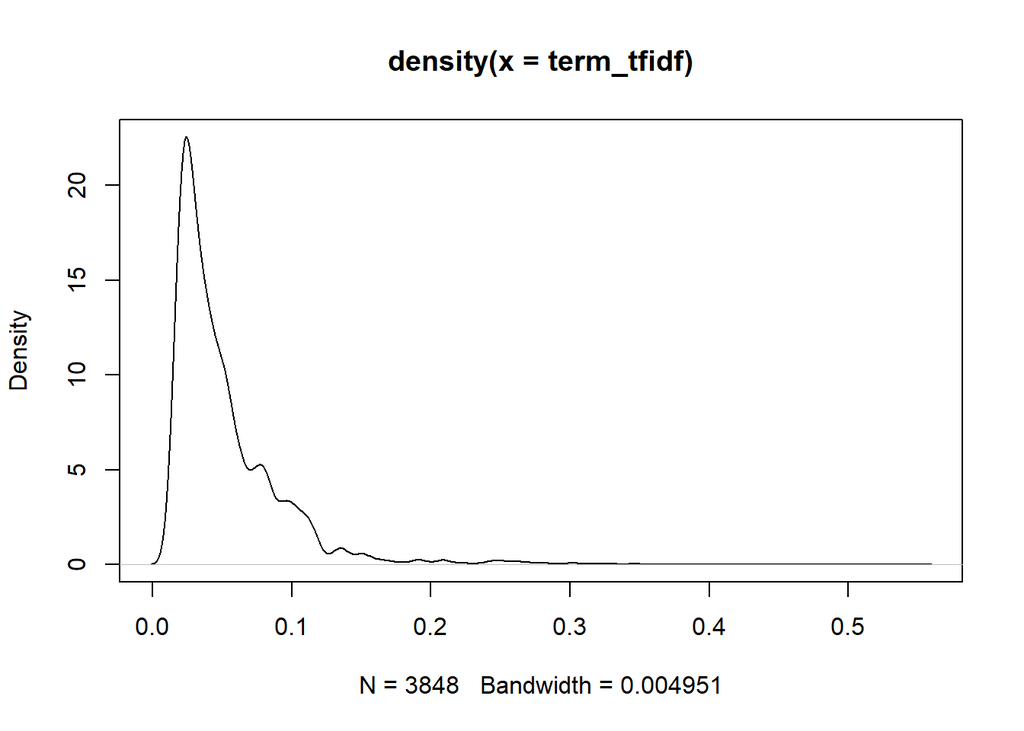

```r
plot(density(term_tfidf))
```

```r
# Trim the DTM file, removing rows (documents) where the sum of term frequencies is zero, and also keep only the terms that have a TF-IDF value greater than or equal to alpha
alpha <- 0.04
text_DTM_trimmed <- text_DTM[row_sums(text_DTM) > 0, term_tfidf >= alpha]
dim(text_DTM_trimmed)
```

```
## [1]  100 1918
```

## 10-fold Cross validation

```r
# Cross validation
control_CTM_VEM <- list(
  estimate.beta = TRUE, verbose = 0, prefix = tempfile(), save = 0, keep = 0,
  seed = as.integer(Sys.time()), nstart=1L, best = TRUE,
  var = list(iter.max=100, tol=10^-6),
  em = list(iter.max=500, tol=10^-4),
  cg = list(iter.max=100, tol=10^5)
)

# use 10-fold CV to determine k!
# randomly divide the data into 10 folds.
set.seed(100)
topics <- c(2, 3, 4, 5, 6, 7, 8, 9, 10, 15) ##set k equals to 2 3 4 5 6 7 8 9 10 15.
seed <- 2
D <- length(data$text)
folding <- sample(rep(seq_len(10), ceiling(D))[seq_len(D)])
table(folding)
```

```
## folding
##  1  2  3  4  5  6  7  8  9 10
## 10 10 10 10 10 10 10 10 10 10
```

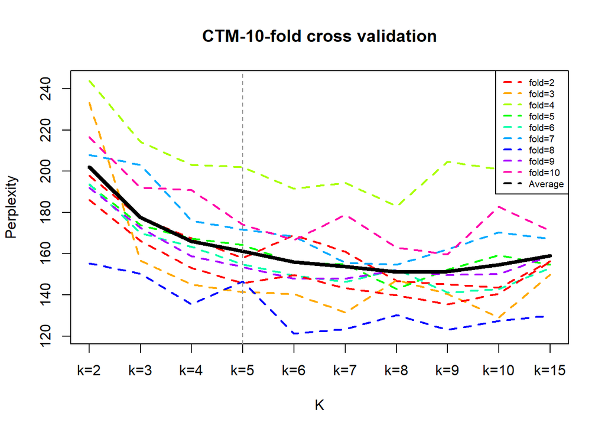

```r
## write a loop to automatically output the perplexity
perp_by_col <- vector()
for (k in topics) {
  perp_by_row <- vector()
  for (chain in seq_len(10)) {
    training <- CTM(text_DTM_trimmed[folding != chain,], k = k,
                    control = control_CTM_VEM)
    testing <- CTM(text_DTM_trimmed[folding == chain,], model = training,
                   control = control_CTM_VEM)
    perp_by_row <- rbind(perp_by_row, perplexity(testing))
  }
  perp_by_col <- cbind(perp_by_col, perp_by_row)
}

# Plot perplexity
transpose <- t(perp_by_col)
matplot(transpose, type = "l", col = rainbow(9), lty = 2, lwd = 2, ylab = "Perplexity", xlab = "K", main = "CTM-10-fold cross validation", xaxt="n")
axis(1, at=1:10, labels = c("k=2", "k=3", "k=4", "k=5", "k=6", "k=7", "k=8", "k=9", "k=10", "k=15"), cex=0.5)

perp_by_col_mean <- colMeans(perp_by_col)

lines(perp_by_col_mean, col = "black", lwd = 4, lty = 1)
led <- c("fold=2", "fold=3", "fold=4", "fold=5", "fold=6", "fold=7", "fold=8", "fold=9", "fold=10", "Average")
legend("topright", led, lwd = 2, lty = 2, col = c(rainbow(9), 'black'), cex = 0.65)

abline(v = 4, col = "gray60", lty = 2)
```

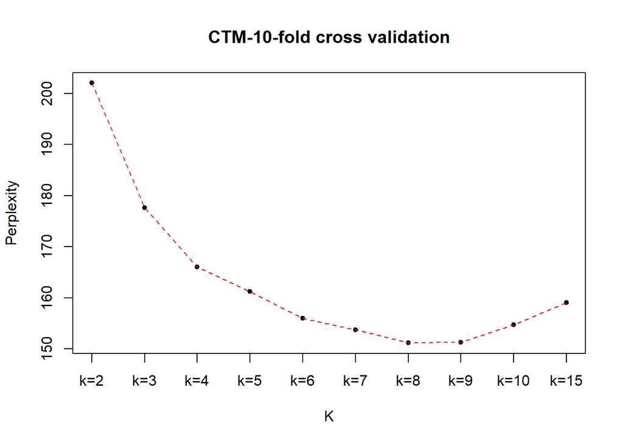

```r
# Average Perplexity
{plot(perp_by_col_mean, pch = 20, ylab = 'Perplexity', xlab = "K", main = "CTM-10-fold cross validation",
      xaxt = "n")
  axis(1, at = 1:10, labels = c("k=2","k=3","k=4","k=5","k=6","k=7","k=8","k=9","k=10","k=15"), cex = 0.5)
  lines(perp_by_col_mean, lwd = 1, lty = 2, col = "red")}
```

## Correlated Topic Model

```r
control_CTM_VEM1 <- list(
  estimate.beta = TRUE, verbose=0, prefix=tempfile(),save=0,keep=0,
  seed=1421313709,nstart=1L,best=TRUE,
  var=list(iter.max=500,tol=10^-6),
  em=list(iter.max=1000,tol=10^-4),
  cg=list(iter.max=500,tol=10^5)
)

################## K = 5 ##################

CTM3 <- CTM(text_DTM_trimmed, k = 8, control = control_CTM_VEM1)
CTM3
```

```
## A CTM_VEM topic model with 8 topics.
```

## Examining the topic model output

```r
## A CTM_VEM topic model with 8 topics.

## Topics
topics3 <- posterior(CTM3)$topics
## Let's look at the probability of each document info fits into each of the topics
topics3 <- as.data.frame(topics3)
rownames(topics3) <- data$name
print(topics3)
```

```
##               1           2           3           4           5           6
## 1   0.964512206 0.004429760 0.004559453 0.004375223 0.004396739 0.004456740
## 2   0.964453850 0.004251094 0.004394906 0.004916718 0.004625491 0.004063761
## 3   0.005514136 0.005324218 0.003972653 0.963456811 0.004613228 0.004014593
## 4   0.004545792 0.004440143 0.964665654 0.004321119 0.004462595 0.004426764
## 5   0.004364173 0.004166922 0.004547745 0.964595061 0.004455425 0.004320384
## 6   0.004254120 0.963973877 0.004430966 0.004636240 0.005417321 0.004011059
## 7   0.004378211 0.004454420 0.004387355 0.004586842 0.004483212 0.964509941
## 8   0.004764232 0.005717456 0.004464290 0.963656628 0.004533588 0.004130254
## 9   0.004243077 0.964285423 0.004299211 0.005278336 0.004725573 0.004055711
## 10  0.004564410 0.964470633 0.004594764 0.004369702 0.004858170 0.004169745
## 11  0.964090775 0.004879038 0.004481439 0.004697797 0.004478162 0.004041645
## 12  0.963853599 0.004259513 0.005233848 0.004542672 0.004285875 0.004869401
## 13  0.004869306 0.004190073 0.005507924 0.004209628 0.963984945 0.004109935
## 14  0.004314814 0.004786125 0.004349680 0.004615734 0.964524006 0.004325305
```

[output cut: 187 more lines]

```r
#Main topic
main_topic3 <- as.data.frame(topics(CTM3))
rownames(main_topic3) <- data$doc_id
colnames(main_topic3) <- "Main_Topic"
print(main_topic3)
```

```
##              Main_Topic
## 12212_10.txt          1
## 12256_9.txt           1
## 8124_8.txt            4
## 6594_10.txt           3
## 9983_7.txt            4
## 1434_10.txt           2
## 11654_9.txt           6
## 7148_9.txt            4
## 1781_10.txt           2
## 9221_10.txt           2
## 3031_7.txt            1
## 4819_7.txt            1
## 7585_10.txt           5
## 12478_9.txt           5
## 3343_10.txt           3
## 6979_10.txt           3
## 7035_10.txt           3
## 7932_10.txt           2
## 1346_7.txt            4
## 430_10.txt            2
## 12306_10.txt          2
## 7425_9.txt            8
## 7731_9.txt            4
## 1429_7.txt            4
## 11449_8.txt           3
## 10496_10.txt          1
## 277_9.txt             8
## 7170_9.txt            4
## 8453_10.txt           6
## 8404_10.txt           5
## 5758_7.txt            7
## 774_8.txt             2
## 6935_9.txt            3
## 10939_8.txt           7
## 5107_10.txt           3
## 1450_10.txt           5
## 1633_8.txt            2
## 5938_10.txt           4
## 2342_10.txt           5
```

[output cut: 46 more lines]

```
## 2329_10.txt           7
## 7140_10.txt           6
## 1654_10.txt           3
## 3790_7.txt            1
## 7861_8.txt            7
## 7471_10.txt           5
## 2866_9.txt            5
## 2151_10.txt           6
## 5796_9.txt            3
## 7843_8.txt            5
## 4117_10.txt           6
## 7118_10.txt           8
## 5782_10.txt           5
## 7088_7.txt            6
## 8952_9.txt            1
```

```r
## Table the documents by topics
main_topic_table3 <- as.data.frame(table(topics(CTM3)))
colnames(main_topic_table3) <- c("Topic", "Frequency")
print(main_topic_table3)
```

```
##   Topic Frequency
## 1     1        12
## 2     2        17
## 3     3        13
## 4     4        17
## 5     5        16
## 6     6        12
## 7     7         9
## 8     8         4
```

```r
## check the sum
sum(table(topics(CTM3)))
```

```
## [1] 100
```

```r
##Let's look at the topics and associated words.
terms(CTM3,10)
```

```
##       Topic 1  Topic 2   Topic 3   Topic 4   Topic 5   Topic 6    Topic 7
##  [1,] "hal"    "flatlin" "danc"    "willi"   "sinatra" "happen"   "skeleton"
##  [2,] "mind"   "franki"  "zombi"   "sure"    "billi"   "jack"     "iwerk"
##  [3,] "taylor" "church"  "beauti"  "critic"  "bad"     "giant"    "disney"
##  [4,] "dad"    "past"    "guy"     "thought" "saw"     "industri" "danc"
##  [5,] "carl"   "huston"  "major"   "found"   "must"    "space"    "comedi"
##  [6,] "grebb"  "joyc"    "mention" "youll"   "humor"   "nuclear"  "anim"
##  [7,] "son"    "featur"  "dirti"   "nice"    "video"   "japanes"  "funni"
##  [8,] "messag" "bright"  "chip"    "bill"    "sister"  "plant"    "seri"
##  [9,] "ditmar" "murder"  "sheet"   "didnt"   "black"   "voyag"    "dodg"
## [10,] "rooney" "impress" "kinkad"  "flynn"   "obvious" "basebal"  "definit"
##       Topic 8
##  [1,] "game"
##  [2,] "flynn"
##  [3,] "worth"
##  [4,] "entertain"
##  [5,] "rememb"
##  [6,] "video"
##  [7,] "past"
##  [8,] "children"
##  [9,] "languag"
## [10,] "parker"
```

```r
topics <- topics3

# Using this: https://www.tidytextmining.com/topicmodeling.html
# Use tidyverse to look at the CTM results a bit more more

tidy_topics <- tidy(CTM3, matrix = "beta")
tidy_topics
```

```
## # A tibble: 15,344 × 3
##    topic term      beta
##    <int> <chr>    <dbl>
##  1     1 aaron 3.23e-22
##  2     2 aaron 6.25e-21
##  3     3 aaron 6.55e-23
##  4     4 aaron 5.47e-22
##  5     5 aaron 1.46e- 3
##  6     6 aaron 1.96e-21
##  7     7 aaron 8.23e-22
##  8     8 aaron 1.39e-12
##  9     1 abl   1.68e- 3
## 10     2 abl   6.61e-21
## # ℹ 15,334 more rows
```

```r
top_terms <- tidy_topics %>%
  group_by(topic) %>%
  slice_max(beta, n = 10) %>%
  ungroup() %>%
  arrange(topic, -beta)

top_terms
```

```
## # A tibble: 80 × 3
##    topic term     beta
##    <int> <chr>   <dbl>
##  1     1 hal    0.0390
##  2     1 mind   0.0188
##  3     1 taylor 0.0152
##  4     1 dad    0.0135
##  5     1 carl   0.0135
##  6     1 grebb  0.0135
##  7     1 son    0.0104
##  8     1 messag 0.0102
##  9     1 ditmar 0.0101
## 10     1 rooney 0.0101
## # ℹ 70 more rows
```

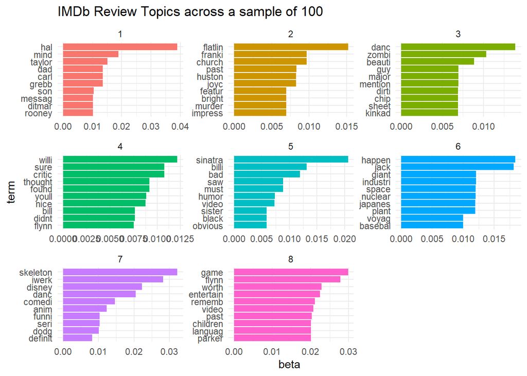

```r
top_terms %>%
  mutate(term = reorder_within(term, beta, topic)) %>%
  ggplot(aes(beta, term, fill = factor(topic))) +
  geom_col(show.legend = FALSE) +
  facet_wrap(~ topic, scales = "free") +
  scale_y_reordered()+
  theme_minimal()+
  labs(title = "IMDb Review Topics across a sample of 100")
```

## Multidimensional scaling to view the topics

```r
# Classical MDS
# N rows (objects) x p columns (variables)
# each row identified by a unique row name

d <- dist(topics) # euclidean distances between the rows

fit <- isoMDS(d, k=2) # k is the number of dim
# If there are identical rows. Run the below only if there are identical rows

#library(vegan)
#fit <- vegan::metaMDS(comm = dist(topics))

fit # view results
```

```
## $points
##              [,1]        [,2]
##   [1,]  0.3090256 -1.52935494
##   [2,]  0.2951896 -1.51585992
##   [3,] -1.4189075 -0.20342647
##   [4,]  0.9185602  1.44338165
##   [5,] -1.4480376 -0.21234380
##   [6,]  1.4608676 -0.51474757
##   [7,]  0.5704927  0.39363937
##   [8,] -1.4182611 -0.20634536
##   [9,]  1.4647832 -0.52255815
##  [10,]  1.4743869 -0.52487577
##  [11,]  0.3023651 -1.52438438
##  [12,]  0.3005297 -1.51710730
##  [13,] -0.8512571  1.28756853
```

[output cut: 90 more lines]

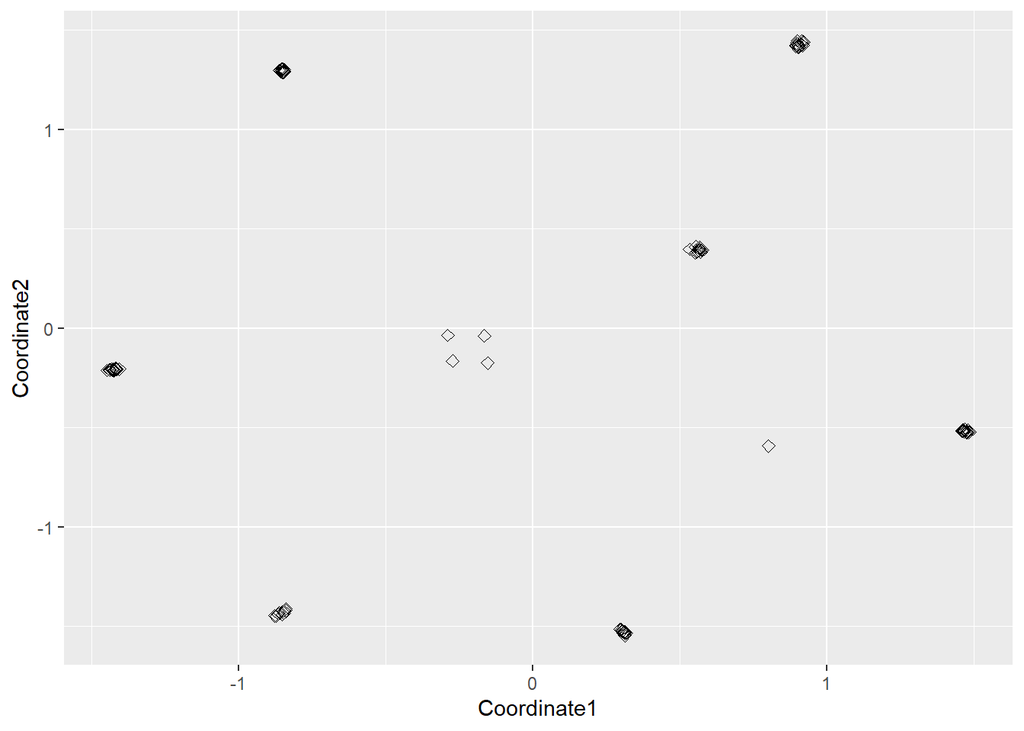

```r
# plot solution
# add the main topic as column 3

plot_data <- as.data.frame(cbind(fit$points[,1], fit$points[,2], main_topic3$Main_Topic),
                                 row.names = data$doc_id)
colnames(plot_data) <- c("Coordinate1", "Coordinate2", "Main_Topic")


(p1 <- ggplot(data = plot_data, aes(x = Coordinate1, y = Coordinate2)) + geom_point(size=2, shape=23))
```

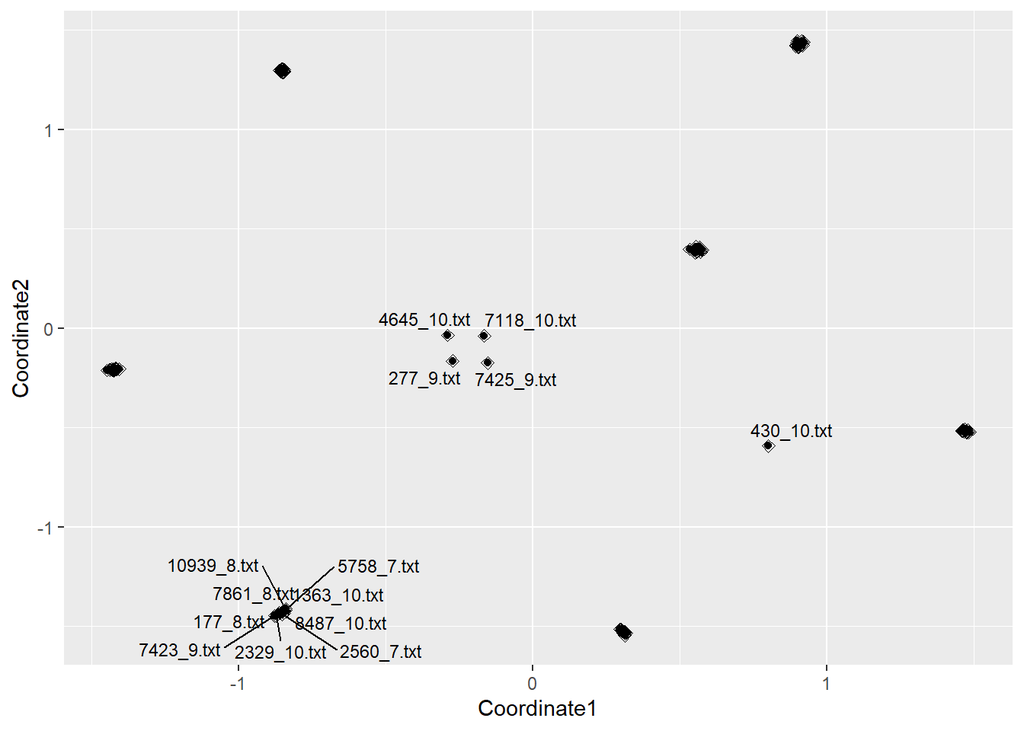

```r
(p2 <- p1 + geom_point() + geom_text_repel(aes(label = row.names(plot_data)), size = 3, max.overlaps = 20))
```

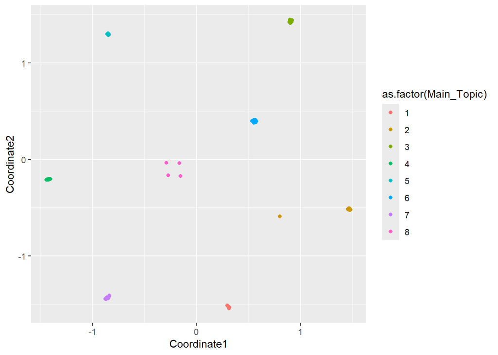

```r
# Need to use as.factor for Main_Topic for aes color so that there is a discrete color palette

(p4 <- ggplot(data = plot_data) +
    geom_point(mapping = aes(x = Coordinate1, y = Coordinate2, color = as.factor(Main_Topic))))
```

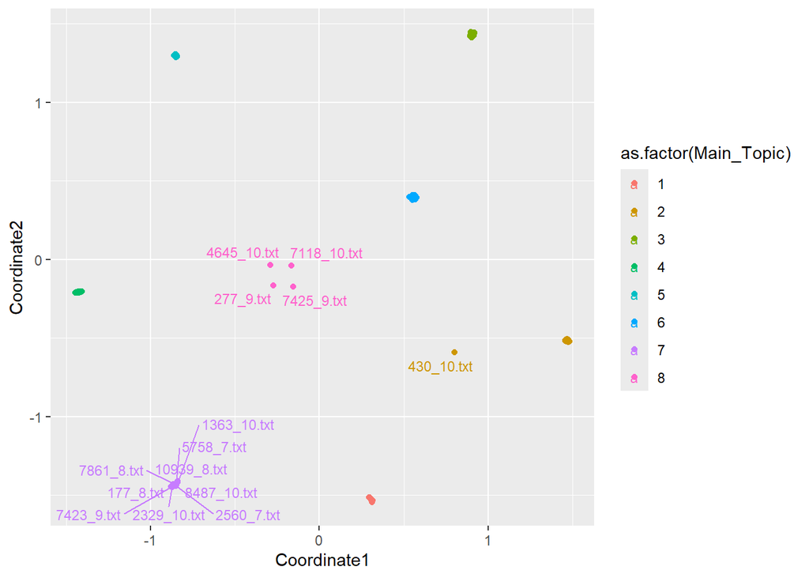

```r
(p5 <- ggplot(plot_data, aes(Coordinate1, Coordinate2, color = as.factor(Main_Topic)))+
    geom_point()+geom_text_repel(aes(label = row.names(plot_data)), size = 3, max.overlaps = 20))
```

## Extension 1: Display the full text of each of the top 3 highest probability documents for each identified topic

```r
## Step 1: Extract the topic probabilities for each document
topics3 <- posterior(CTM3)$topics
topics3 <- as.data.frame(topics3)
rownames(topics3) <- data$name  # Ensure the document names are retained

# View the first few rows of the topics probabilities
head(topics3)
```

```
##             1           2           3           4           5           6
## 1 0.964512206 0.004429760 0.004559453 0.004375223 0.004396739 0.004456740
## 2 0.964453850 0.004251094 0.004394906 0.004916718 0.004625491 0.004063761
## 3 0.005514136 0.005324218 0.003972653 0.963456811 0.004613228 0.004014593
## 4 0.004545792 0.004440143 0.964665654 0.004321119 0.004462595 0.004426764
## 5 0.004364173 0.004166922 0.004547745 0.964595061 0.004455425 0.004320384
## 6 0.004254120 0.963973877 0.004430966 0.004636240 0.005417321 0.004011059
##             7           8
## 1 0.004326784 0.008943094
## 2 0.004489179 0.008805000
## 3 0.004095961 0.009008400
## 4 0.004420351 0.008717580
## 5 0.004835601 0.008714688
## 6 0.004075707 0.009200709
```

```r
## Step 2: Identify the top 3 highest probability documents for each topic
top_docs <- list()

# Loop through each topic to find the top 3 documents
for (topic_num in 1:ncol(topics3)) {
  # Get the document indices with the highest probabilities for the current topic
  top_docs[[topic_num]] <- head(order(topics3[[topic_num]], decreasing = TRUE), 3)
}

# Print the top 3 documents for each topic
top_docs
```

```
## [[1]]
## [1] 66 89 26
##
## [[2]]
## [1] 42 81 10
##
## [[3]]
## [1]  4 35 71
##
## [[4]]
## [1]  5 58 23
##
## [[5]]
## [1] 45 84 98
##
## [[6]]
## [1] 29 99 76
##
## [[7]]
## [1] 86 83 85
##
## [[8]]
## [1] 97 22 77
```

```r
## Step 3: Display the full text of the top 3 documents for each topic
# Iterate through each topic to extract the full text of the top 3 documents
for (topic_num in 1:length(top_docs)) {
  cat("\nTopic", topic_num, ":\n")

  # Get the top 3 document indices for the current topic
  top_indices <- top_docs[[topic_num]]

  # Extract the corresponding document names and texts
  top_doc_names <- rownames(topics3)[top_indices]
  top_texts <- data$text[top_indices]

  # Display the document names and their full texts
  for (i in 1:length(top_indices)) {
    cat("\nDocument", top_doc_names[i], ":\n")
    cat(top_texts[i], "\n\n")
  }
}
```

```
##
## Topic 1 :
##
## Document 66 :
## Mickey Rooney (as Mi Taylor) is a young man drifting along the figurative road to ruin, where he meets 12-year-old Elizabeth Taylor (as Velvet Brown) - she adores horses, but he has a sad history with the animals. Ms. Taylor is enamored with Mr. Rooney's horse-sense; she takes him home, and gets …
##
##
## Document 89 :
## The big names in film tried to do their part for the war effort, and Charlie Chaplin was no exception. This patriotic and propagandist picture is part of his contribution, although the war was nearly over by the time of its release. The tramp goes to war, humorously accomplishes acts of heroism a…
##
##
## Document 26 :
## Enigma is a computer part which scrambles Russian messages, so that America can't understand them. They can only be read by the intended recipient. The Americans know that the Russians are going to transmit a message revealing the plans of five political assassinations they want to carry out.<br …
##
##
## Topic 2 :
##
## Document 42 :
## This movie is excellent in how it portrays the reality of sexual abuse. The daughters perfectly express their conflicting emotions of affection and betrayal. The on-location scenery is absorbingly authentic, and the soundtrack is unobtrusive yet moving. This film is a graduate-level course in a r…
##
##
## Document 81 :
## There is no plot. There are no central characters. There are no moving cameras or close-ups. In fact, this film does not follow any of the conventional storytelling techniques used by mainstream film. However, Roy Andersson's Du Levande is a remarkable piece of cinematic storytelling. It is a tou…
##
##
## Document 10 :
## I adored this, but I am an 80's kid. I loved Rainbow Bright my whole childhood. I don't know if little ones these days would be very interested in the show, mine wasn't. (But thats okay, I bought it for me anyway. I just brought the little one so the guy at the checkout stand wouldn't look at me …
##
##
## Topic 3 :
##
## Document 4 :
## To regard the film as nothing more than a documentary about skateboarding would fail to recognize several important aspects of Dogtown. Peralta (a well- known skateboarding figure himself) has crafted a film that not only deals with the birth of what we know today as skateboarding, but also exami…
##
##
## Document 35 :
## When it opened in London during the Christmas season of 1969 this musical version of James Hilton's famous story was drubbed by the critics. The same reception greeted it when it opened in the US, prompting MGM to withdraw its "Roadshow" status and cut almost all of its songs. What a mistake!!!<b…
##
##
## Document 71 :
```

[output cut: 56 more lines]

```
## In 1929, director Walt Disney and animator Ub Iwerks changed the face of animation with the release of the very first installment of their "Silly Symphonies" series, "The Skeleton Dance". Iwerks and Disney had been collaborating together since the early 20s, in Disney's "Laugh-O-Gram" cartoon ser…
##
##
## Topic 8 :
##
## Document 97 :
## I don't play video games at all but my children do.<br /><br />I got a big kick out of this. Would like to see more of this type of film. "very cool" as my youngest would say.<br /><br />Interesting characters and the overall story line was interesting. Like I said I don't play video games but I …
##
##
## Document 22 :
## A true comedy.The dialog is fast and very witty.Eleanor Parker at her physical peak .Flynn as only Flynn can be"the charming rogue'..although now past his prime.. Most of the scenes between the principals are short so the movie moves well. If you haven't seen this movie please give a look.You wil…
##
##
## Document 77 :
## twenty years later, this movie still remains as entertaining as when you first watched it. In a movie market overrun by toilet humor, graphic violence and foul language, it's refreshing to be fully entertained for two hours by such a clean movie.
```

## Extension 2: Additional Visualization (Showing that the topics are not correlated)

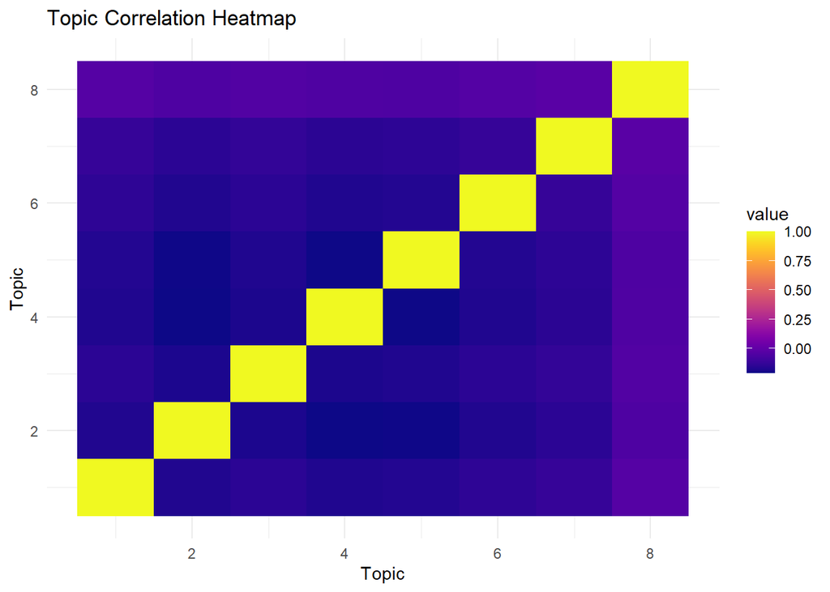

```r
# Compute correlation matrix between topics
topic_correlation <- cor(topics3)

# Plot heatmap
library(viridis)
library(reshape2)
ggplot(melt(topic_correlation), aes(Var1, Var2, fill = value)) +
  geom_tile() +
  scale_fill_viridis(option = "C") +
  theme_minimal() +
  labs(title = "Topic Correlation Heatmap", x = "Topic", y = "Topic")
```

## Extension 3: Exploring the Distribution of Ratings Across Topics (Each document is assigned to the topic with the highest probability)

```r
# Extract ratings from file names (e.g., "1_10.txt" -> 10)
data$rating <- gsub(".*_(\\d+)\\.txt", "\\1", data$doc_id)

# Convert the extracted ratings to numeric (this ensures they are treated as numbers, not strings)
data$rating <- as.numeric(data$rating)

# Check the structure of the ratings column to make sure it's numeric
str(data$rating)
```

```
##  num [1:100] 10 9 8 10 7 10 9 9 10 10 ...
```

```r
# Assign the topic with the highest probability to each document
topic_assignments <- apply(topics3, 1, which.max)
data$assigned_topic <- topic_assignments  # Add the assigned topic to the data

# Aggregate ratings by assigned topic
ratings_by_topic <- data %>%
  group_by(assigned_topic) %>%
  summarise(total_ratings = sum(rating, na.rm = TRUE))

# View the result to make sure aggregation works
ratings_by_topic
```

```
## # A tibble: 8 × 2
##   assigned_topic total_ratings
##            <int>         <dbl>
## 1              1           102
## 2              2           156
## 3              3           126
## 4              4           148
## 5              5           145
## 6              6           111
## 7              7            77
## 8              8            38
```

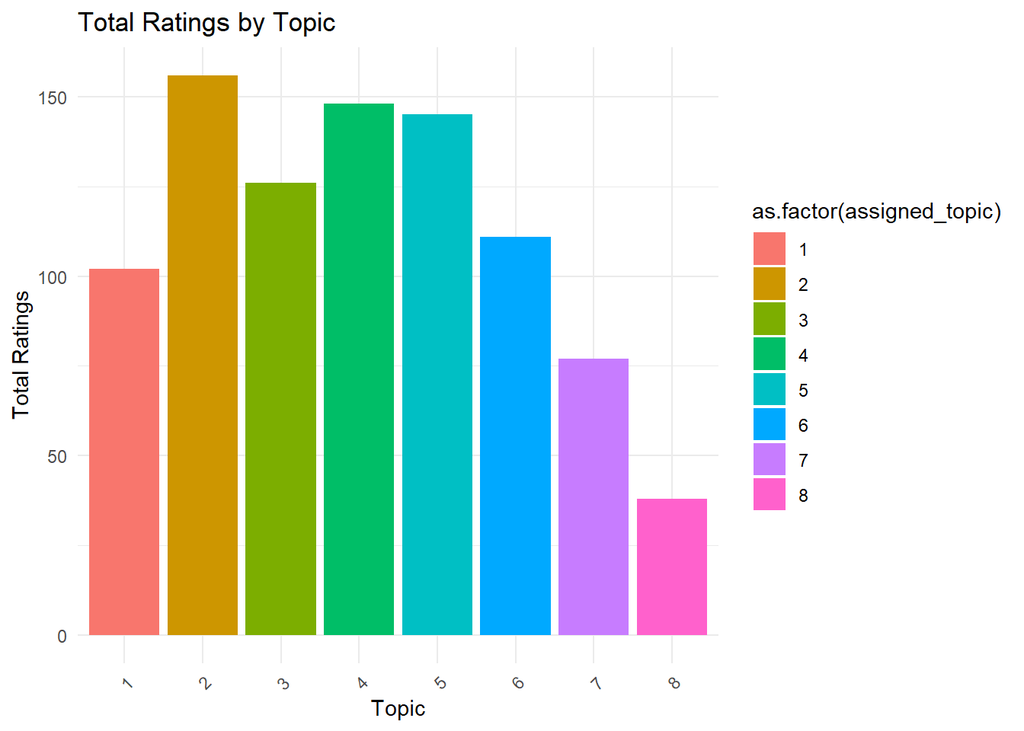

```r
# Visualize the total ratings per topic
ggplot(ratings_by_topic, aes(x = as.factor(assigned_topic), y = total_ratings, fill = as.factor(assigned_topic))) +
  geom_bar(stat = "identity") +
  labs(title = "Total Ratings by Topic", x = "Topic", y = "Total Ratings") +
  theme_minimal() +
  theme(axis.text.x = element_text(angle = 45, hjust = 1))
```

```r
# Filter and create the frequency table for ratings per topic
rating_distribution_by_topic <- data %>%
  filter(rating %in% c(10, 9, 8, 7)) %>%  # Filter for ratings 10, 9, 8, 7
  group_by(assigned_topic, rating) %>%
  summarise(count = n()) %>%
  spread(key = rating, value = count, fill = 0)  # Spread ratings as separate columns
# View the result
print(rating_distribution_by_topic)
```

```
## # A tibble: 8 × 5
## # Groups:   assigned_topic [8]
##   assigned_topic   `7`   `8`   `9`  `10`
##            <int> <dbl> <dbl> <dbl> <dbl>
## 1              1     4     1     4     3
## 2              2     1     5     1    10
## 3              3     0     1     2    10
## 4              4     4     3     4     6
## 5              5     2     2     5     7
## 6              6     1     2     2     7
## 7              7     2     3     1     3
## 8              8     0     0     2     2
```

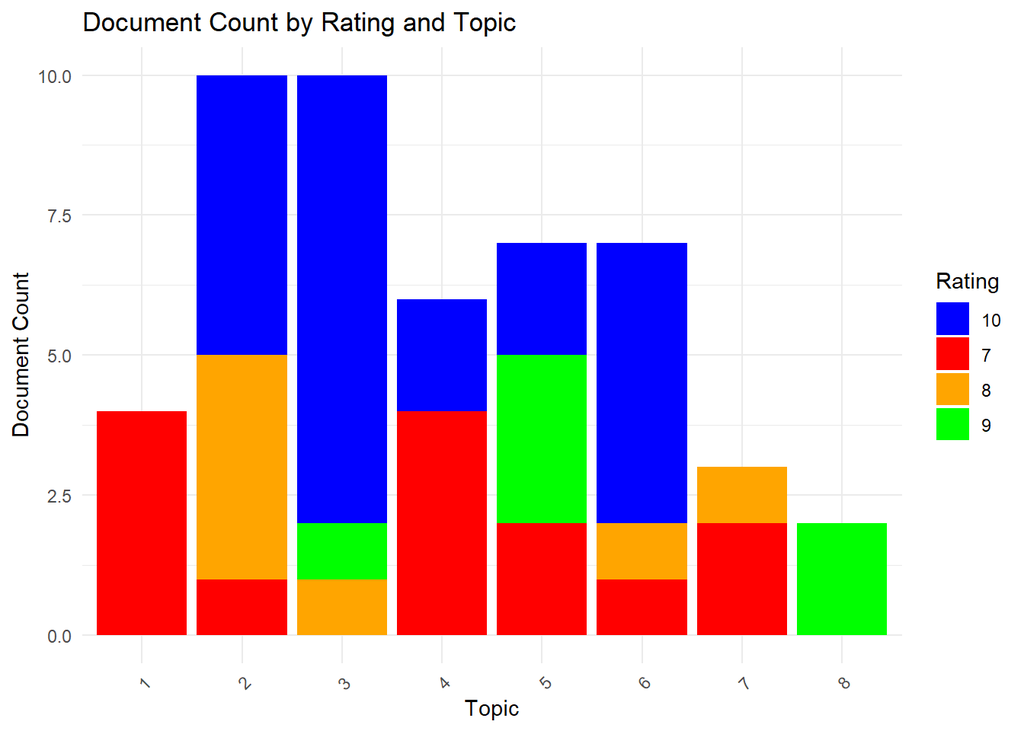

```r
# Visualize the distribution of ratings for each topic
ggplot(rating_distribution_by_topic, aes(x = as.factor(assigned_topic))) +
  geom_bar(aes(y = `10`, fill = "10"), stat = "identity", position = "stack") +
  geom_bar(aes(y = `9`, fill = "9"), stat = "identity", position = "stack") +
  geom_bar(aes(y = `8`, fill = "8"), stat = "identity", position = "stack") +
  geom_bar(aes(y = `7`, fill = "7"), stat = "identity", position = "stack") +
  labs(title = "Document Count by Rating and Topic", x = "Topic", y = "Document Count") +
  scale_fill_manual(values = c("10" = "blue", "9" = "green", "8" = "orange", "7" = "red"),
                    name = "Rating") +
  theme_minimal() +
  theme(axis.text.x = element_text(angle = 45, hjust = 1))
```

## Research Proposal: Using Correlated Topic Models to Analyze International Trends in Postsecondary Education Policies

## Purpose of the Study

The purpose of this study is to use Correlated Topic Models (CTM) for text mining to analyze education policies over time. Specifically, this study examines trends, shifts, and the frequency of policy themes related to access to postsecondary education. This study aims to identify thematic patterns within a large dataset of policy texts with the intent of offering insights into how government and institutions have addressed access to postsecondary education over time.

## Supporting Research Literature

The use of text mining in education policy analysis is supported by a growing body of literature that demonstrates its ability to reveal trends and patterns in policy development. Lee (2023) focuses on the South Korean government’s education policies regarding artificial intelligence. Using text mining, this paper analyzed government publications, press releases, and reports from 2020 to 2022 revealing how key tasks and policy directions evolved over time. This study highlights the utility of text mining in extracting keywords and analyzing trends within policy documents, providing insights into the development of educational strategies. The research conducted by Li and Xue (2022) demonstrates the application of topic modeling to explore policy changes in teacher ethics in China. By analyzing high-frequency words within policy texts, the authors were able to trace the evolution of policy objectives and content, showcasing how text mining can reveal shifts in educational policy focus over time. Using this method aids in understanding the current landscape of education policies and provides historical context for their development. Rofiah et. al (2023) perform a content analysis to examine evolving education trends through policy documents. This approach allows for a comprehensive understanding of the complexities surrounding educational issues and factors influencing policy changes. By integrating text mining with qualitative analysis, Rofiah et. al illustrate that researchers can gain a multifaceted perspective on the dynamics of education policies. These studies collectively support the argument that text mining and topic modeling are valuable tools for identifying themes and trends in education policy.

## Why CTM?

CTM extends Latent Dirichlet Allocation (LDA) by allowing topics to be correlated rather than assuming they are independent. This is critical for analyzing policy documents, as education policies often contain overlapping themes such as socioeconomic equality, equity, funding mechanisms, and institutional accountability. CTM enables the identification of co-occurring policy themes, providing a nuanced understanding of how different policies interact and even evolve.

## Research Questions

To what extent have themes related to access to postsecondary education evolved over time in education policies? What are the most prominent policy themes, and how do they correlate with one another? How do the frequencies and relationships of these themes vary across regions and time periods?

## Data

Using the World Education Reform Database (WERD), a public dataset containing over 10,000 documented policy changes from 189 countries, this study will use key variables such as country, year of the policy, reform title, and the reform description.

## Methodology

The CTM framework involves two main components: topic distribution and word distribution. Topic distribution assigns probabilities to documents associated with specific topics and word distribution identifies probabilities of words being associated with particular topics.

### The Generalized Equation for CTM

The generalized equation for the CTM is:

$$p(\theta, z, w \mid \alpha, \beta) = p(\theta \mid \alpha) \prod_{n=1}^N
p(z_n \mid \theta) p(w_n \mid z_n, \beta)$$

Where $\theta$ represents the topic distribution, $z$ represents the topic assignments, $w$ represents the words in the documents, $\alpha$ is the Dirichlet prior for topic distributions, and $\beta$ is the topic-word distributions.

The model will provide a probabilistic distribution of topics for each policy, enabling clustering and classification of policies based on shared themes.

## Expected Findings

This analysis from this study is expected to find an emergence of key themes such as equity, affordability, and institutional accountability in postsecondary education policies. There may also be some correlations between policy themes such as the intersection of affordability initiatives and equity-focused reforms.

## Significance and Implications

The findings can inform future policy development by identifying trends and thematic correlations. This study will provide policymakers and stakeholders with insights into the evolution of postsecondary education policy priorities. Furthermore, this study will add to the growing literature that highlights the utility of text mining techniques as a methodology for education policy researchers.